# Chapter 13

# Scene 6

**Prompt:** So, with rstanarm models, at least, `predict()` doesn’t (ever?) work. Instead, we need to use `posterior_linpred()`. But it sure is confusing! Continuing with our simple case of one new female observation, use `posterior_linpred()`, understand its outputs, and the provide a graphical display of those outputs. (Hint: Check the class of the output. It isn’t a tibble!)

```r
# predicts likelihood of getting a dvote from a new data point (just a female)
predict <- posterior_linpred(z_stan, transform = TRUE, newdata = g)
mean(predict)
```

```
## [1] 0.4643222
```

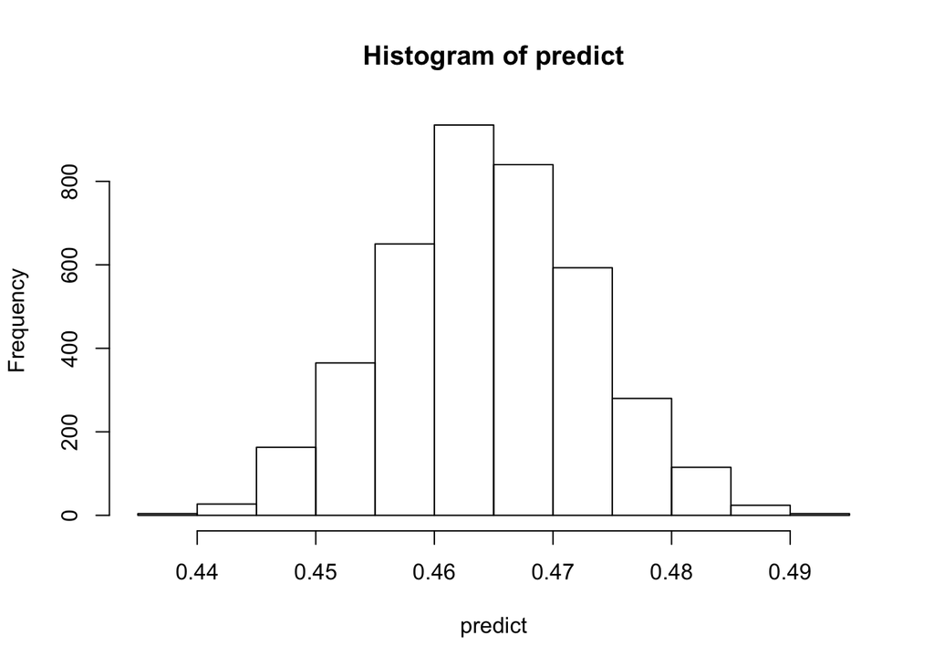

```r
hist(predict)
```

```r
# predict() just gives you a point answer - new female? prediction is 46%, doesn't give you any uncertainty
# posterior_predict gives you thousands of answers because adds uncertainty
  # uncertainty of the forecast
# posterior_linpred gives you a different answer: what's your best guess for the likelihood of voting and whats the certainty around that guess?
  # uncertainty of the mean
```

# Scene 7

**Prompt:** Estimate a new model of `dvote`, this time with two explanatory variables: `gender` and `real_ideo`. (Like last time, you should treat `real_ideo` as a continuous variable.) Redo most of the above explorations with this new model.

```r
stan_glm(dvote ~ gender + real_ideo, data = x, refresh = 0, family = "binomial")
```

```
## stan_glm
##  family:       binomial [logit]
##  formula:      dvote ~ gender + real_ideo
##  observations: 6653
##  predictors:   3
## ------
##                  Median MAD_SD
## (Intercept)       3.4    0.1
## gendernon-female -0.1    0.1
## real_ideo        -0.9    0.0
##
## ------
## * For help interpreting the printed output see ?print.stanreg
## * For info on the priors used see ?prior_summary.stanreg
```

# Scene 8

**Prompt:** So far, we have pooled all our data together. But what if we wanted to estimate a different model for each year. Do that with our gender/real_ideo explanatory variables! (Might want to see how *PPBDS* [does that](https://davidkane9.github.io/PPBDS/13-classification.html#fitting-many-models-using-map-1).)

# Scene 9

**Prompt:** Now that you have an object with many models. Can you tell us the election in which men/women were most split in their voting? How about in which election ideology mattered most? How about which election this model worked “best” for? Are there other interesting questions which we can explore?

# Scene 10

**Prompt:** Let’s make a plot! Page 207 has a graph which shows the association between income and voting across these years. Make a similar plot, but for `gender` and `real_ideo`. Does the latest version of ggplot make this easier?